# Взаимосвязи в компании: отчет

Подолин Дмитрий, dpodolin

```r
library(tidytext) # обработка текста
library(ggplot2) # графики
library(wordcloud2) # облака слов
library(tidyr) # переформатирование таблиц (длинный - широкий формат, например)
library(stringr) # обработка строк (удаление, поиск, замена символов)
library(dplyr) # преобразование данных
library(ggraph)
```

Загрузка данных

```r
library(igraphdata)
library(igraph)
data(enron)
library(lubridate)
source("~/shared/minor2_2023/2-tm-net/hw/personalTask2.R")
# если у вас выдает ошибку для такой загрузки -- замените файл на personalTask2.R (см.ниже)
#source("~/shared/minor2_2023/2-tm-net/hw/personalTask2.R")
start_date = hw_net_get_start_date()
# определяем конечную точку месяца
last_date = start_date + dmonths(1)
time = as_date(as_datetime(E(enron)$Time))
# убираем вершины раньше начальной точки и позже конечной
net = enron %>% delete_edges(E(enron)[time < start_date | time > last_date])
# убираем связи вершины самой с собой (согласно данным, иногда люди себя в копию ставят)
net = igraph::simplify(net, remove.multiple = F)
# убираем обособленные вершины
net = net %>% delete_vertices(V(net)[degree(net) == 0])
```

Анализируются данные с 2001-05-02 по 2001-06-01 10:30:00

## Описание сети

Для начала посмотрим на саму сеть: на ее составляющие - атрибуты, которые присущи как вершинам, так и ребрам, чтобы понимать с чем мы можем здесь работать. Еще им номера присвоим для удобства.

```r
vertex_numbers <- 1:vcount(net)  # Создаем вектор с номерами для каждой вершины - на всякий случай
V(net)$id <- vertex_numbers

# Получение атрибутов вершин в виде data.frame
vertex_attrs <- get.data.frame(net, what = "vertices")
# Получение атрибутов ребер в виде data.frame
edge_attrs <- get.data.frame(net, what = "edges")
```

Попытаемся её каким то образом визуализировать:

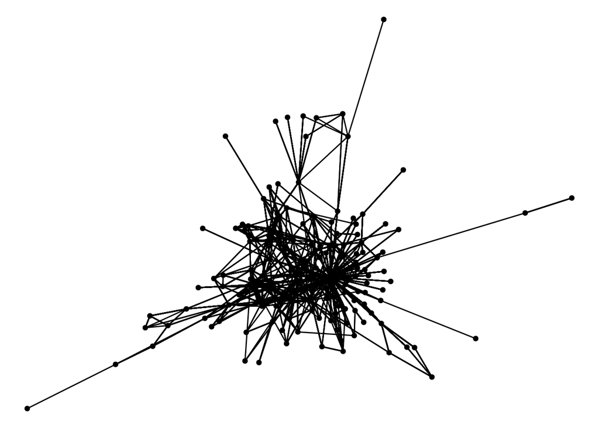

```r
g = net
plotlayout <- ggraph::create_layout(g, "fr")

# Визуализация сети с подходящим стилизованным графом
ggraph(g, layout = plotlayout) +
  geom_edge_link() +
  geom_node_point() +
  theme_void()
```

Никакого существенного вывода отсюда не извлечь, кроме как, разве что, вывод о том что, визуально, вроде как здесь нет большого разделения на отдельные комьюнити. Проверим это позже.

### Выявление значимых вершин

**Использованные меры центральности:**

```r
degree(net) #про количество связей у каждой вершины
```

```
##   [1]   46   30   10  119   13  226   20   80   25   11   10   53  154   18    1
##  [16]    5   21   58   22   22    4  109  154   29   87   24   54  152   84   18
##  [31]   71    8   11   51   50    8   41  385   89   46   12    7   34   72  836
##  [46]   42   83    5   74 1018   31  217  179   63    8   35   36    4   85   26
##  [61]   22   21  204   24   31   31 1494   34   36   16   32   60   19   41   11
##  [76]  182   61   42   10  137   23   29  153   28   47    8   22    1  121    9
##  [91]  189   10  110    4  119  208   67   40  155   23   25   23   24   30  132
## [106]   71  168   34    6    6   49   13   38    9   12   12   15  274    6   10
## [121]    8  220  825   65   25   41   18    5   14   20  265   46  139   26   38
## [136]   34  124  207  525   10  166   10   33   28  276    1   46   30   18   47
## [151]   24   20    9    8
```

```r
#ВТОРОЕ - ПРО БИТВИННОСТЬ - логика, что если такую вершину убрать, то двигаться большинству придется дольше, чтобы добраться из А в Б
betweenness(net)
```

```
##   [1]  613.9936578   37.8862831    0.0000000  937.6689323   11.4468628
##   [6]  787.0333222    0.0000000 1337.9004089    1.0000000  258.3459048
##  [11]   24.6070600  268.6401641  428.7605701    0.0000000    0.0000000
##  [16]    0.0000000    0.0000000   70.2882144    0.0000000    0.0000000
##  [21]    0.0000000  286.2518167  614.9641793  258.8352009  235.8323101
##  [26]   22.8599724  667.9387952  627.1065690  114.9052489    0.0000000
##  [31]  686.4702837    0.0000000    0.0000000    0.0000000    0.0000000
##  [36]   12.7049249  192.0000000  675.9552978   32.9396549    0.0000000
##  [41]    0.0000000    1.4444444    0.0000000  129.3323291  283.1955898
##  [46]    0.0000000  380.9784391    0.0000000   82.8702222  111.0979888
##  [51]    0.1818182  984.4894207  188.6809395  253.1584041    0.0000000
##  [56]    0.0000000    0.0000000    0.9208951  317.8348371    0.0000000
##  [61]    0.0000000    0.4615385 1720.1605559    7.9482266  295.0615230
##  [66]    0.0000000 8699.0179095    0.0000000  148.4069385    1.8158523
##  [71]    0.0000000    0.0000000   15.9442551   95.0000000  127.1111111
```

[output cut: 16 more lines]

```r
#ТРЕТЬЕ - ПРО БЛИЖАЙШАЯ КО ВСЕМ ВЕРШИНА
closeness(net)
```

```
##   [1] 0.0025510204 0.5000000000          NaN 0.0029325513 0.0022026432
##   [6] 0.0026809651          NaN 0.0015408320 1.0000000000 0.0012706480
##  [11] 0.0013020833 0.0026246719 0.0019880716          NaN 0.0015772871
##  [16]          NaN          NaN 0.0017953321          NaN 0.0016313214
##  [21] 0.0014430014 0.0030395137 0.0023094688 0.0012706480 0.2500000000
##  [26] 0.0018656716 0.0015552100 0.0019646365 0.0019723866          NaN
##  [31] 0.0019801980          NaN          NaN 0.0025125628          NaN
##  [36] 0.0010764263 0.3333333333 0.0023041475 0.0025974026          NaN
##  [41]          NaN 0.0010752688 0.0019157088 0.0022271715 0.0031250000
##  [46]          NaN 0.0024154589 1.0000000000 0.0013386881 0.0024271845
##  [51] 0.0019120459 0.0021598272 0.0022123894 0.0023041475 0.0018832392
##  [56]          NaN 0.0018587361 0.0017301038 0.0030120482 0.0018832392
##  [61]          NaN 0.1428571429 0.0027322404 0.0017985612 0.0012787724
##  [66] 0.0015408320 0.0039682540          NaN 0.0020576132 0.0020533881
##  [71]          NaN 0.0015408320 0.0026881720 0.0019193858 0.0012578616
```

[output cut: 16 more lines]

Попытка нарисовать сеть с акцентом на центральности у меня всё крашит, поэтому рассмотрим параметр - вершины с макимальным параметром одной из трех метрик центральности:

```r
degree_cent = degree(net)
betweenness_cent = betweenness(net)
closeness_cent = closeness(net)
clean_closeness_values <- na.omit(closeness_cent)

# Нахождение узла с наибольшими значениями центральности
max_degree_node <- which(degree_cent == max(degree_cent))
max_betweenness_node <- which(betweenness_cent == max(betweenness_cent))
max_closeness_node <- which(clean_closeness_values == max(clean_closeness_values))

# Вывод результатов
print(paste0("Node with the maximum degree centrality: ", max_degree_node))
```

```
## [1] "Node with the maximum degree centrality: 67"
```

```r
print(paste0("Node with the maximum betweenness centrality: ", max_betweenness_node))
```

```
## [1] "Node with the maximum betweenness centrality: 67"
```

```r
print(paste0("Node with the maximum closeness centrality: ", max_closeness_node))
```

```
## [1] "Node with the maximum closeness centrality: 7"
## [2] "Node with the maximum closeness centrality: 35"
## [3] "Node with the maximum closeness centrality: 83"
## [4] "Node with the maximum closeness centrality: 84"
```

Отсюда можно сделать некоторые выводы:

### Выявление сообществ

**Использованные меры выделения сообществ:**

```r
#1 алгоритм edge.betweenness
comm1 = edge.betweenness.community(net)
membership(comm1)
```

```
##   [1]   1   2   3   4   5   6   7   6   8   9  10  11  12  13  14  15  16  17
##  [19]  18  19  20  21  22  23  24  25  26   6  27  28  29  30  31  32  33  34
##  [37]  35   6  36  32  37  38  32  39  40  41  42  43  32  40  44   6  32  45
##  [55]  46  39  32  47  48  49  50  51   6  52  53  12  32  32  32  54  55  12
##  [73]  56  57  58   6  32  59  60  32  61  62   6  63  64  65  66  67  32  68
##  [91]  32  69   6  70  71   6   6  72  27  73  74  75  76  77  32   6  32  32
## [109]  78  79  32  80  81  82  83  84  85  32  86  87  88  40  40  89  32  32
## [127]  90  91  92  93   6  32  32  94  95  96  32   6  40  97   6  98  99 100
## [145]   6 101 102  32  32  32 103  32 104 105
```

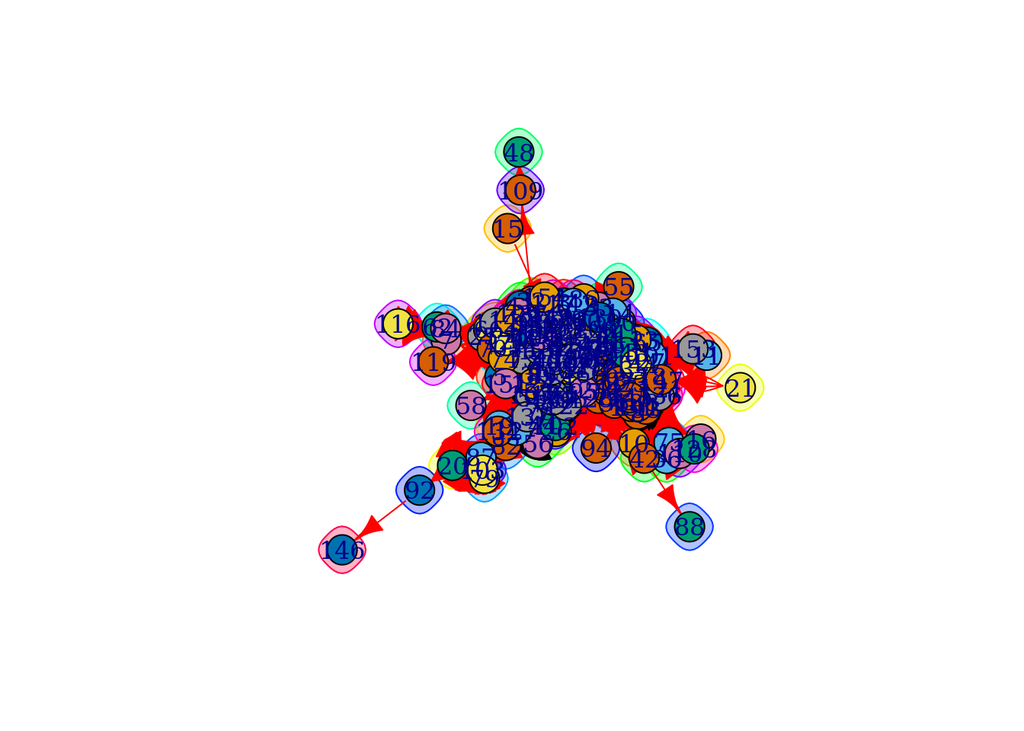

```r
plot(comm1,net)
```

```r
modularity(comm1)
```

```
## [1] 0.4102089
```

```r
#2 алгоритм - walktrap
comm3 = walktrap.community(net)
membership(comm3)
```

```
##   [1]  4  4  4  4  2  7 11  6  4  6  3  4  8  4 12  6  4  7  2 13  7  2  7  4 14
##  [26]  2  3  7  9  4  3  4  4  4  9  6  4  7  2  4  4  6  4  1  1  9 10 15  9  1
##  [51]  4  7  2  2  9 16  4  2  2  4  4 17  3  4  3  8  4  4  4  4  4  8  4  8  6
##  [76]  7  9  1  5  4  4  5  7 18  3  4  5 19  2  4  2 20 10  7  7 10  7  4  9  4
## [101]  3  1  5  4  9  3  2  4 21  6  9  4  9  4  4 22  4  9  8  4  7  1  1  2  4
## [126]  4  2  6  4  4 10  4  4  2  4  7  2 10  1  4 10  4  9  7 10 23  7  4  4  9
## [151]  2  4  3  4
```

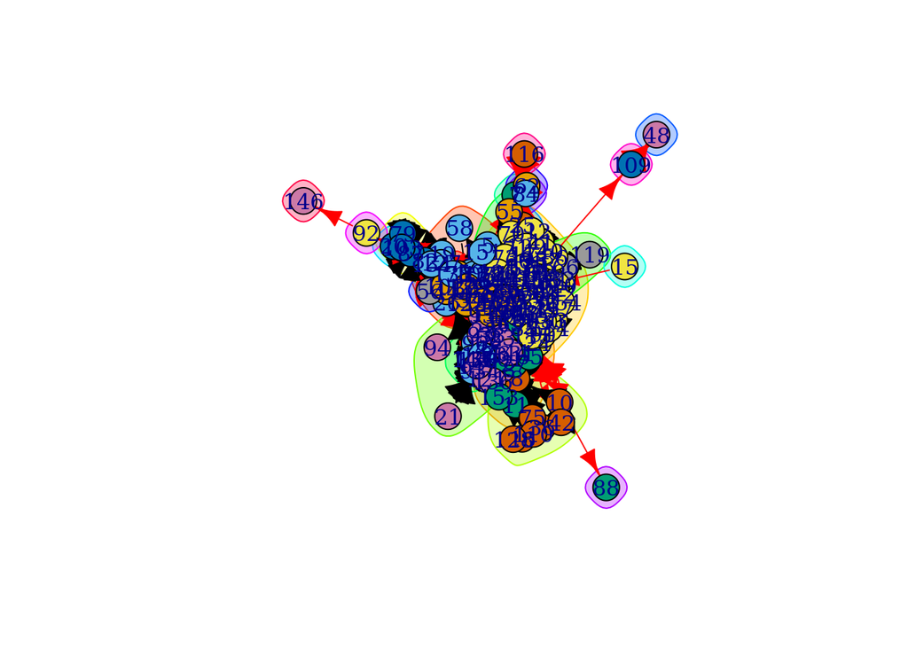

```r
plot(comm3,net)
```

```r
modularity(comm3)
```

```
## [1] 0.6037702
```

По значению modularity видно, что разбиение по алгоритму walktrap более точное, поэтому в дальнейшем буду часто к нему обращатся.

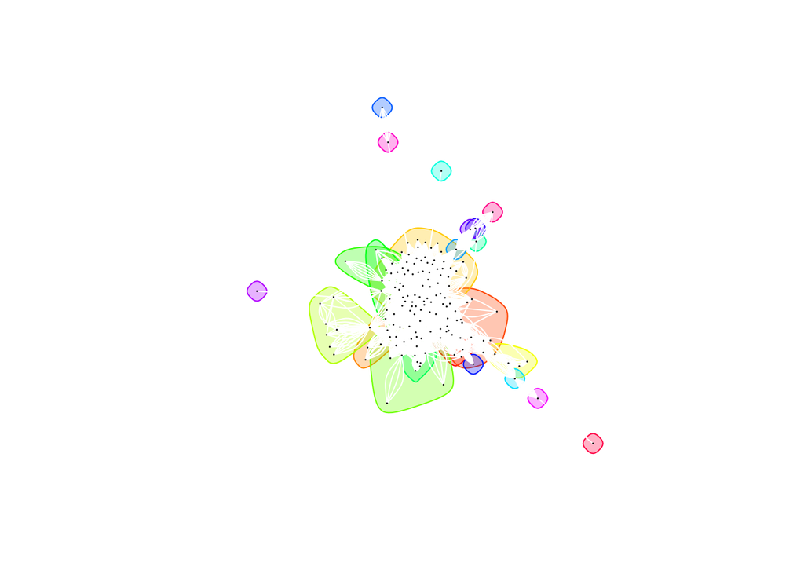

```r
plot(comm3,net,vertex.label=NA,vertex.size=0.01,edge.arrow.size = 0, edge = 0, vertex = 0)
```

### Исследовательские вопросы

**Вопрос 1: Посмотрим на вершины - людей которые связывают отдельные комьюнити в наибольшей степени - мосты**

Посмторим на мосты согласно самому точному из двух алгоритмов разбиения на коммъюнити(согласно метрике - modularity) - алгоритм - walktrap.

```r
library(igraph)
g <- net

# Разбиваем граф на сообщества с использованием метода walktrap
walktrap_communities <- walktrap.community(g)

# Находим вершины-мосты в графе
find_bridges <- function(graph) {
  # Используем метод edge_betwenness для вычисления центральности ребер
  edge_betweenness_values <- edge_betweenness(graph)

  # Плучаем рёбра с самой большой центральностью
  max_betweenness_edges <- which(edge_betweenness_values == max(edge_betweenness_values))

  # Получаем вершины, соответствующие выбранным рёбрам
  bridges <- ends(graph, E(graph)[max_betweenness_edges])

  return(unique(bridges))  # Возвращаем уникальные вершины-мосты
}

# Вызываем функцию для нахождения вершин-мостов в графе
graph_bridges1 <- find_bridges(g)
```

```r
library(igraph)
g <- net

# Разбиваем граф на сообщества с использованием метода walktrap
walktrap_communities <- walktrap.community(g)

# Находим вершины-мосты в графе на основе центральности ребер (betweenness)
find_bridges <- function(graph) {
  # Используем метод edge_betweenness для вычисления центральности ребер
  edge_betweenness_values <- edge_betweenness(graph)

  # Получаем рёбра с наибольшей центральностью (betweenness)
  max_betweenness_edges <- which(edge_betweenness_values == max(edge_betweenness_values))

  # Получаем вершины, соответствующие выбранным рёбрам
  bridges <- ends(graph, E(graph)[max_betweenness_edges])

  return(unique(bridges))  # Возвращаем уникальные вершины-мосты
}

# Вызываем функцию для нахождения вершин-мостов на основе центральности рёбер (betweenness)
graph_bridges2 <- find_bridges(g)
```

```r
vertex_attrs %>% filter(id == "6" | id == "67")
```

```
##            Email           Name               Note id
## 1 barry.tycholiz Barry Tycholiz     Vice President  6
## 2  john.lavorato  John Lavorato CEO, Enron America 67
```

Вот два важных человека для всей компании по следующим причинам:

1)Проводники информации: Люди-мосты часто выступают в роли носителей информации между разными группами. Они могут передавать и распространять идеи, знания и ценности от одного сообщества к другому, что способствует распространению информации и расширению горизонтов.

2)Сохранение целостности сети: Люди-мосты играют важную роль в поддержании целостности социальной сети. Благодаря своим связям с различными сообществами они способствуют сохранению связности и разнообразия всей сети.

3)Социальная интеграция: Люди-мосты способствуют социальной интеграции, поскольку связывают людей из разных сред и культур. Они могут стать катализаторами для сближения и взаимопонимания между различными группами.

**Вопрос 2: Влияет ли одинаковая должность на формирование связей между сотрудниками**

```r
g = net

#посмотрим на наше значение ассортативности
assortativity_real = assortativity_nominal(g,as.factor(V(g)$Note), directed = T)

#проведем тест ассортативности - случайные связи
number_of_permutations = 2000
assortativity_shuffled  <- rep(NA, number_of_permutations)
for(i in 1:number_of_permutations){
  V(g)$attr_shuffled = sample(V(g)$Note, replace = F)
  assortativity_shuffled[i] = assortativity_nominal(g,as.factor(V(g)$attr_shuffled), directed = T)}
result <- assortativity_nominal(net, as.factor(V(net)$Note))
print(result)
```

```
## [1] 0.03688493
```

```r
q <- quantile(assortativity_shuffled, c(0.05, 0.95))

odn_pvalue = sum(assortativity_shuffled <= assortativity_real) / number_of_permutations
odn_pvalue
```

```
## [1] 0.943
```

Мы получили односторонний p-value равный 0.94, значит наша нулевая гипотеза о том что нет влияния должности сотрудника на формирование связей посредством сообщений e-mail - оправдана.

## Место сотрудника в сети

```r
hw_net_get_vertex(net) #"Lawrence May"
```

```
## [1] "Lawrence May"
```

```r
vertex_attrs %>% filter(Name == "Lawrence May")
```

```
##       Email         Name     Note id
## 1 larry.may Lawrence May Director 85
```

Мне достался “Lawrence May”: имейл - larry.may; должность(note) - Director; его номер - 85 Сравним его центральность относительно средней величины центральности всего графа(по 2 метрикам).

[figure not shown]

```r
#Просчеты
a = mean(degree(net))

b = mean(betweenness(net))

c = degree(net)[85]

d = betweenness(net)[85]

# Установка и загрузка библиотек
library(ggplot2)

# Предположим, у вас есть данные по значениям центральности
specific_node_centralities <- c(a, b)    # Значения центральности для выбранной вершины
average_centralities <- c(c, d)           # Средние значения центральности для сравнения

# Создание dataframe для построения гистограммы
data <- data.frame(
  Metric = c("Metric degree", "Metric betweenness"),
  Lawrence_May = specific_node_centralities,
  Average = average_centralities
)

# Преобразование данных в длинный формат для ggplot
data_long <- tidyr::gather(data, key = "Variable", value = "Value", -Metric)

# Построение гистограммы с парами столбцов
ggplot(data_long, aes(x = Metric, y = Value, fill = Variable)) +
  geom_bar(stat = "identity", position = "dodge") +
  labs(title = "Comparison of Centralities",
       x = "Metric", y = "Centralities") +
  theme_minimal()
```

Посмотрим какому коммъюнити принадлежит Lawrence May.

```r
membership(comm3)[85]#увидели что принадлежит коммъюнити 3
```

```
## [1] 3
```

```r
qq = unlist(comm3[3])
length(qq) #увидели что в нем всего 9 человек.
```

```
## [1] 9
```

```r
vertex_attrs %>% filter(vertex_attrs$id %in% qq)#смотрим на людей из его коммъюнити согласно алгоритму walktrap
```

```
##              Email             Name           Note  id
## 1   charles.weldon   Charles Weldon             NA  11
## 2    dutch.quigley               NA             NA  27
## 3 errol.mclaughlin Errol McLaughlin       Employee  31
## 4      john.arnold      John Arnold Vice President  63
## 5    john.griffith               NA             NA  65
## 6        larry.may     Lawrence May       Director  85
## 7       matt.smith               NA             NA 101
## 8       mike.maggi    Michael Maggi       Director 106
## 9         v.weldon   Charles Weldon             NA 153
```

Теперь мы знаем теоретических друзей, близких коллег или просто собеседников, которые влияют на нашего Lawrence May в большей мере(и наоборот соответсвенно). Значит мы например через них можем косвенно влияет на Lawrence May в наших корыстных целях.

## Общие выводы

Мною был проведен сетевой анализ некоторой организации, в результате которого я совершил: 1)Сотрудников с наибольшими мерами центральности по трем метрикам - важные узлы для взаимодействия внутри компании. 2)Выявил сообщества людей внутри компании по 2 разным метрикам, предпочел одну из них в силу ее большей точности, а в результате имею понимание принципа деления на группы внутри сообщества - важная информация, открывающая доступ к юольшому количеству возможных махинаций с сотрудниками. 3)Обнаружил, исходя из двух метрик, 2 человек - связывающих большее количество сообществ, и подробно сформулировал пользу от полученной информации - смотреть выше перед вторым вопросом. 4)Определил что наличие одинаковых должностей не влияет на формирование связей внутри компании, что означает например отсутсвие сговора между нижайшем персоналом против верхушки(а почему бы и нет:) ) 5)На конкретного человека разыскал его сообщество, членов его сообщества, выяснил значимость его в сети(через меры центральности) а значит и внутри сообщества тоже.